# Bullshit

Original study: http://journals.plos.org/plosone/article?id=10.1371/journal.pone.0153419

“Bullshit is used as a technical term, defined as communicative expression that lacks plausibility and truth.” Example:

- Hidden meaning transforms unparalleled abstract beauty.
- Imagination is inside exponential space time events.

## Data

Sample: 196 US citizens (43.4% women, 36.4 years old on average) recruited on Amazon Mechanical Turk.

Assignment:

1. Rate the profoundness of each statement on a 5-point Likert-scale ranging from 1 - not at all profound, through 2 - somewhat profound, 3 - fairly profound, 4 - definitely profound, to 5 - very profound.
2. Rate the favorableness of three potential Democratic candidates and three Republican candidates for US president on a 5-point Likert scale ranging from 1 - very unfavorable, through 2 - somewhat unfavorable, 3 - neither unfavorable nor favorable, 4 - somewhat favorable, to 5 - very favorable.
3. Estimate theirself political liberalism/conservatism using 7-point Likert scale (1 - liberal, 7 - conservative).

Some of the statements for the evaluation were bullshit, some - simple mundane statements (e.g., “A wet person does not fear the rain”).

## Analysis

- For every subject the average bullshit receptiveness was calculated.
- Correlations of bullshit receptiveness with conservativeness and favourableness values were estimated with Spearman coefficient.
- To test if it’s significantly different from 0, t-test was used.

## Results

- favorable views of Cruz, Rubio, Trump
- conservatism.

## Raw data

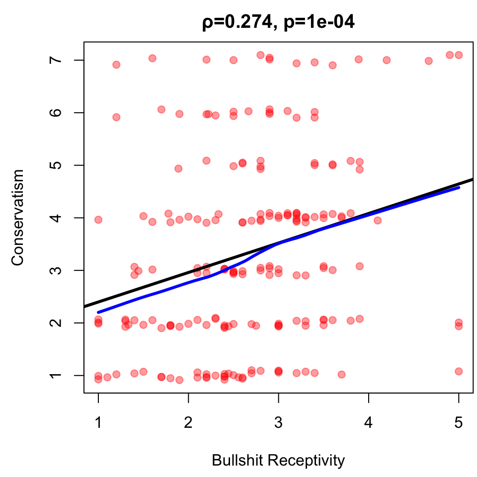

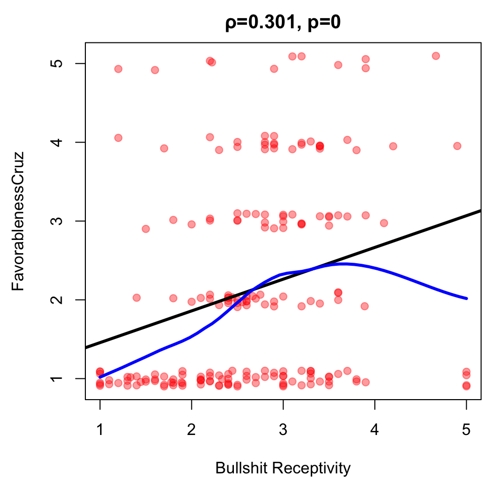

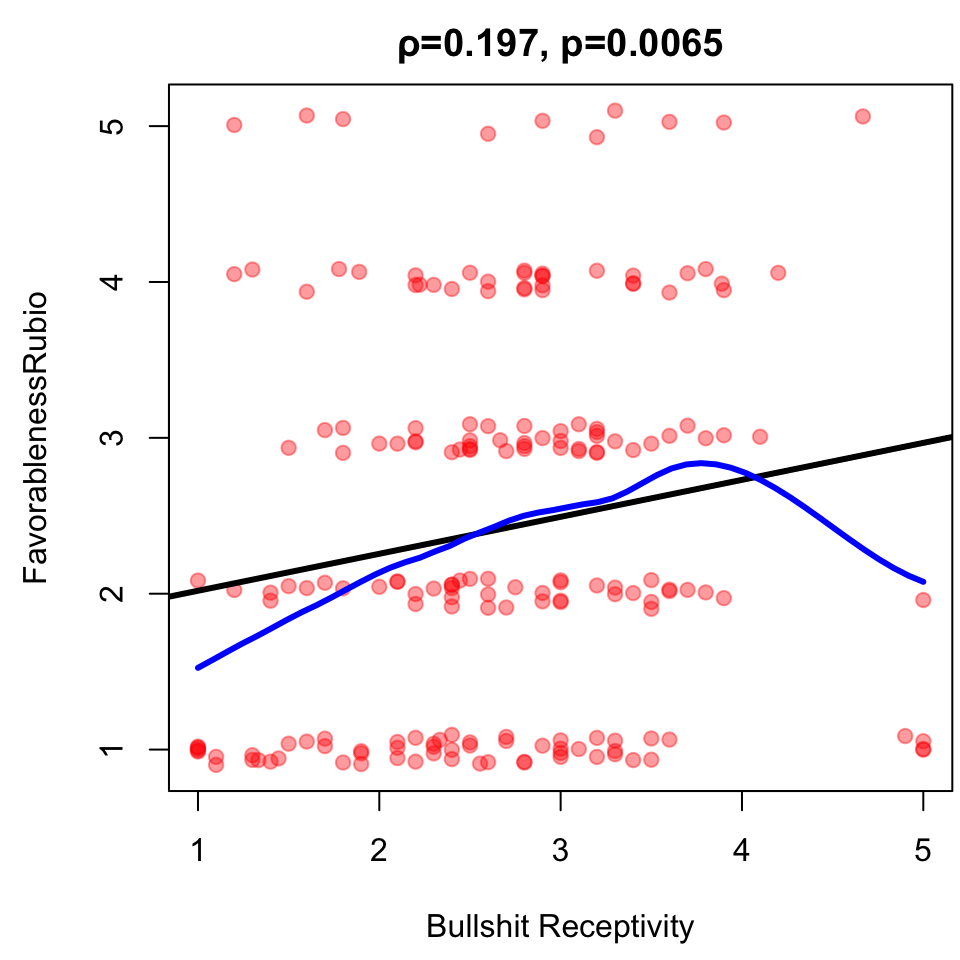

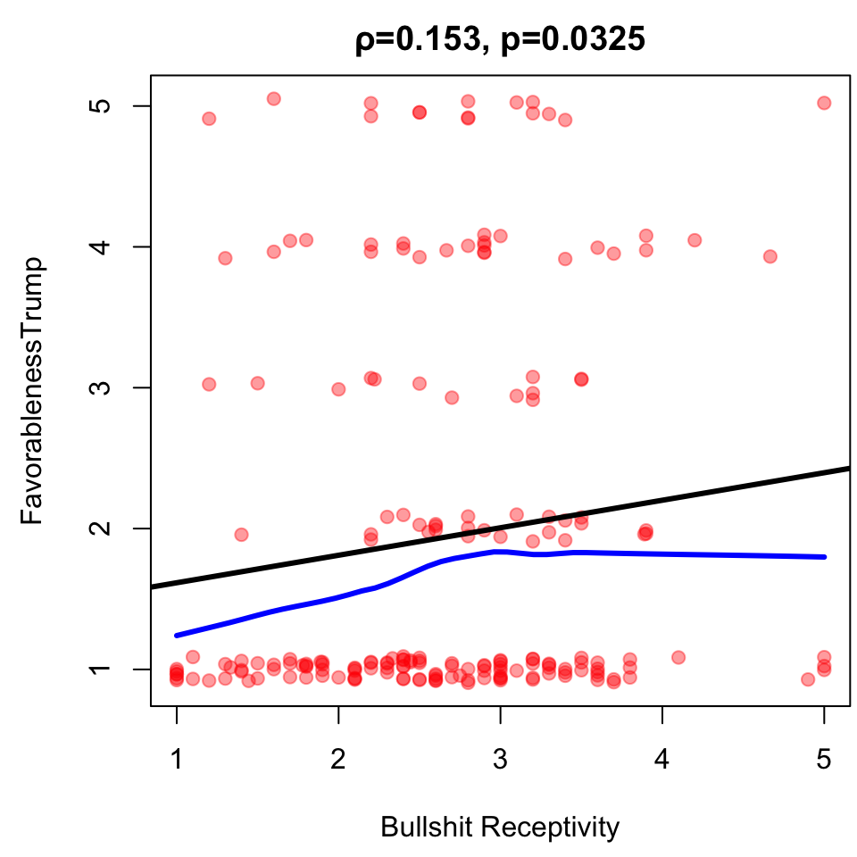

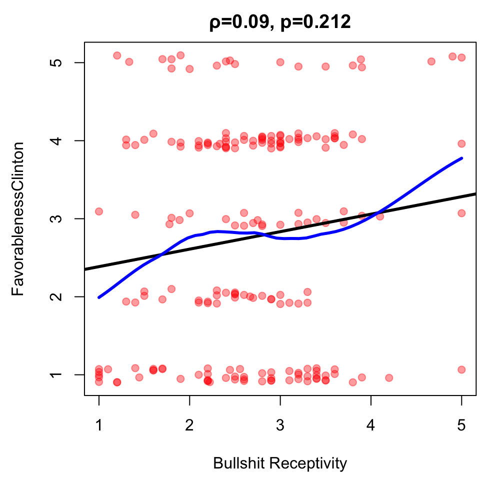

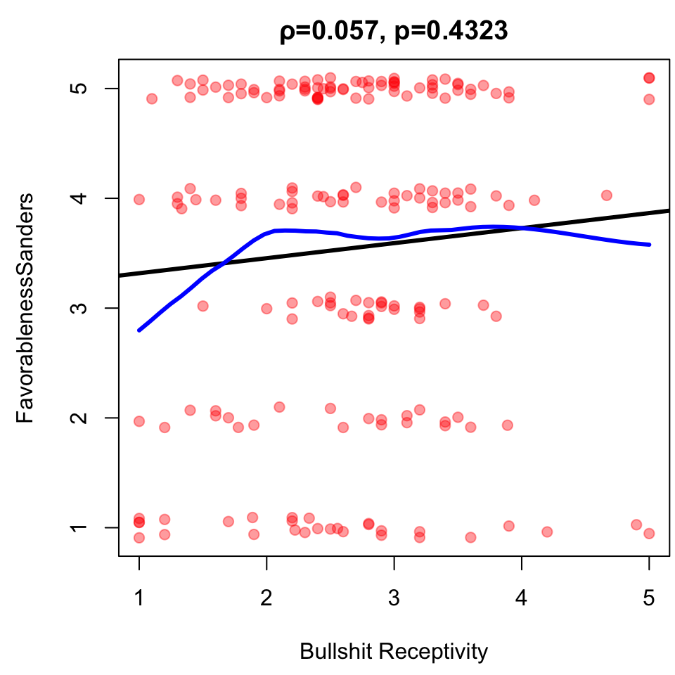

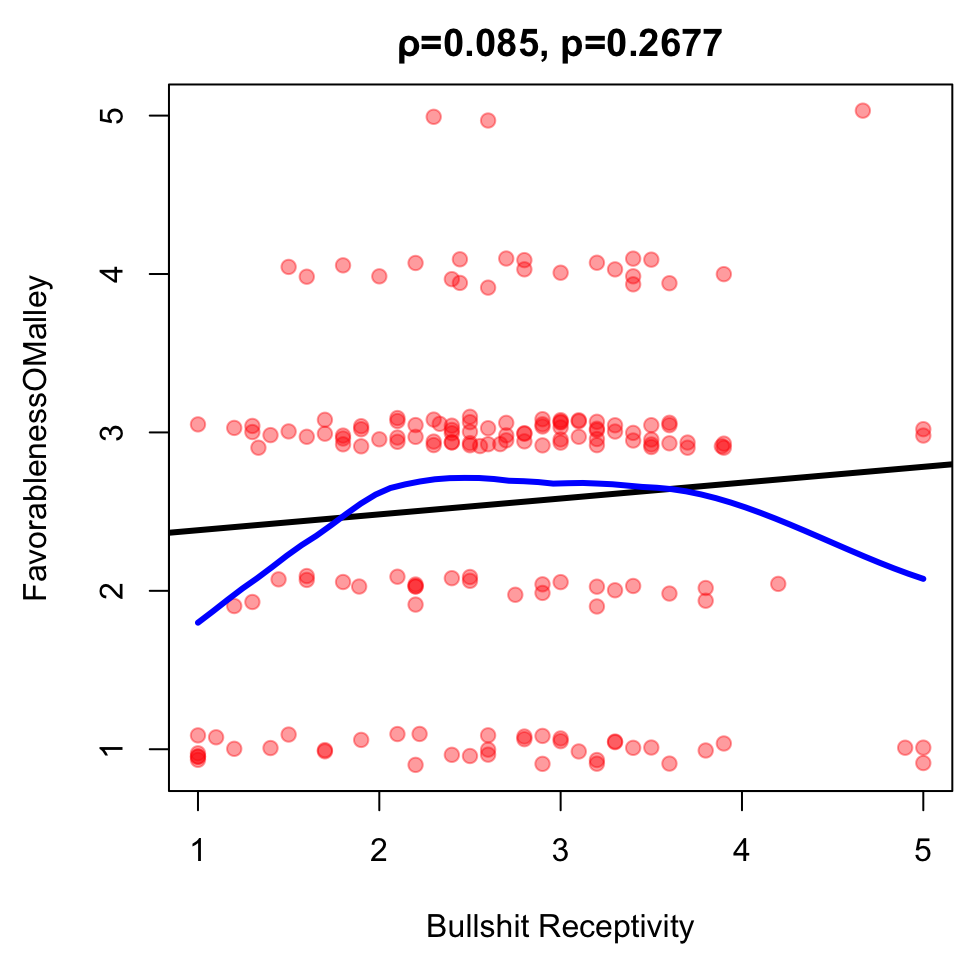

## Criticism

- Sample is not representative of the population
- Unbalancedness:

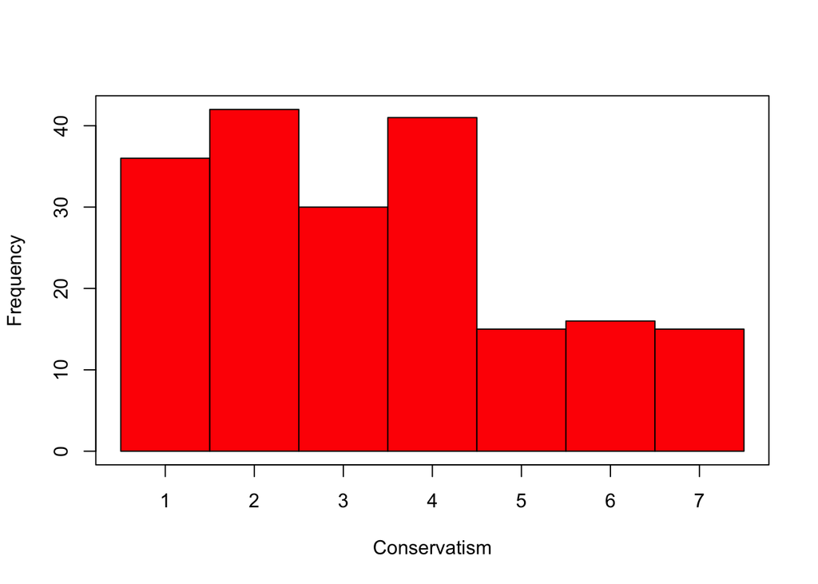

- One of the features is not continuous

Overall, plots and coefficients tell different stories.

Pfattheicher, S., & Schindler, S. (2016). Misperceiving bullshit as profound is associated with favorable views of Cruz, Rubio, Trump and conservatism. PLoS ONE, 11(4), 1–7.